# Genetic diversity

### 1. Heterozygosity

```r
het
```

```
## # A tibble: 8 × 5
##   INDV                  `O(HOM)` `E(HOM)` N_SITES     F
##   <chr>                    <dbl>    <dbl>   <dbl> <dbl>
## 1 Pop-A-L-37_Pop-A-L-37     3333    1874.    3678 0.809
## 2 Pop-A-L-7_Pop-A-L-7       3289    1838.    3605 0.821
## 3 Pop-A-S-20_Pop-A-S-20     3249    1933.    3786 0.710
## 4 PopA-S-1_PopA-S-1         3012    1894.    3709 0.616
## 5 PopC-L-11_PopC-L-11       3008    1630.    3196 0.880
## 6 PopC-L-2_PopC-L-2         3180    1762.    3449 0.841
## 7 PopC-S-16_PopC-S-16       3279    1824     3572 0.832
## 8 PopC-S-4_PopC-S-4         3206    1777.    3484 0.837
```

Can you calculate this in R, and assign individual heterozygosity to a new column? You will also notice that there is no “population” column, and we will need one. Can you use the the available information (hint: see previous code) to assign a population column? (hint 2: why might the variable names be causing an error?)

```r
het$Heterozygosity <- 1-(het$`O(HOM)`/het$N_SITES) #The back ticks get around the parentheses in the variable name
het$Population <- c(rep("large",2),rep("small",2),rep("large",2),rep("small",2))
```

For the rest of this course we will be using ggplot2 for our plots - if you have no experience using this package, take 5-10 minutes to familiarise yourself by searching for an online tutorial. Here is one example:

[http://www.noamross.net/blog/2012/10/5/ggplot-introduction.html]

Basically, `ggplot()` builds up a plot in layers. We first tell R what we want to plot, then we tell it how to plot it (e.g. with points, boxplot etc.)

We can use `ggplot2` to plot `heterozygosity` against population. We will start off defining the aesthetics, which produces a blank plot. by using the function `geom_point()`, as follows:

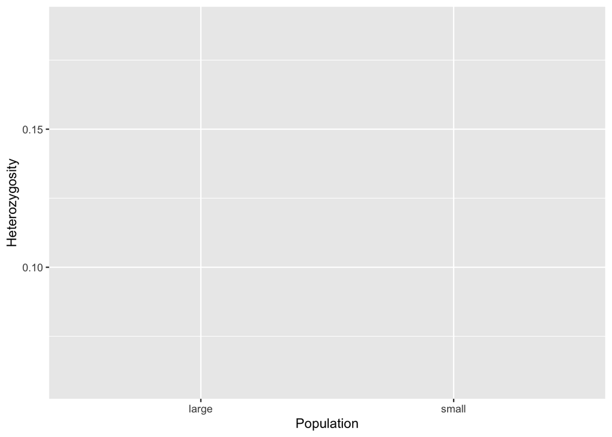

```r
#Make a plot
A <- ggplot(het,aes(x = Population, y = Heterozygosity))

#Call the plot up
A
```

Can you figure out how to now tell ggplot to add points to the plot?

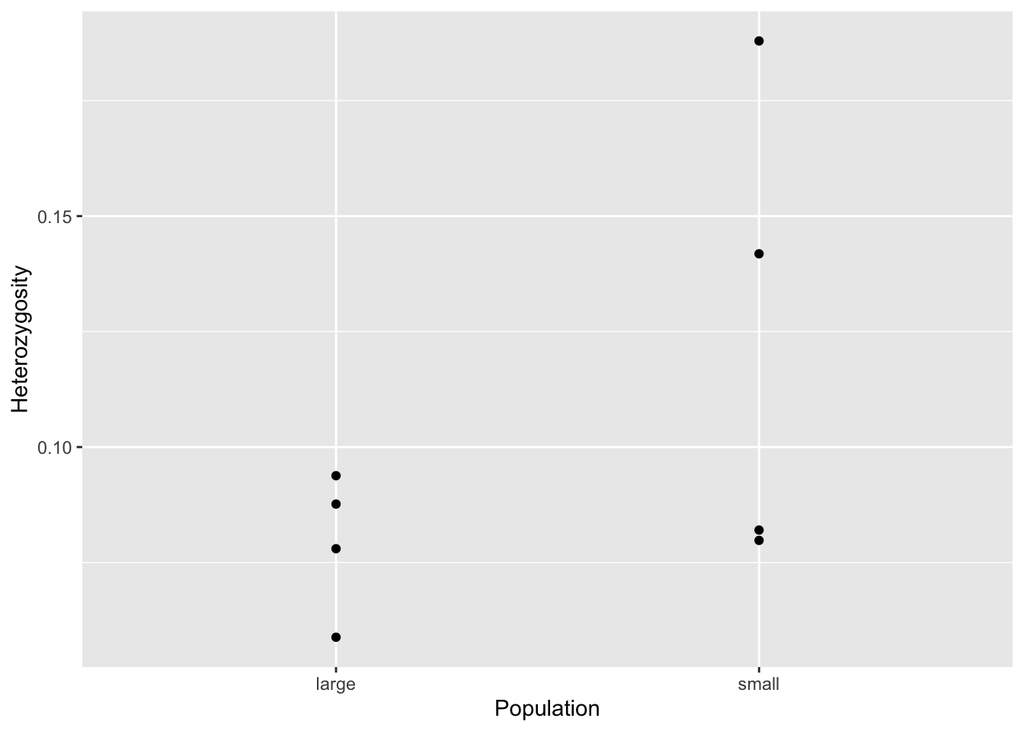

```r
A <- ggplot(het,aes(x = Population, y = Heterozygosity)) +
  geom_point()

A
```

This is already pretty close to what we are after. We just need to colour the points by population:

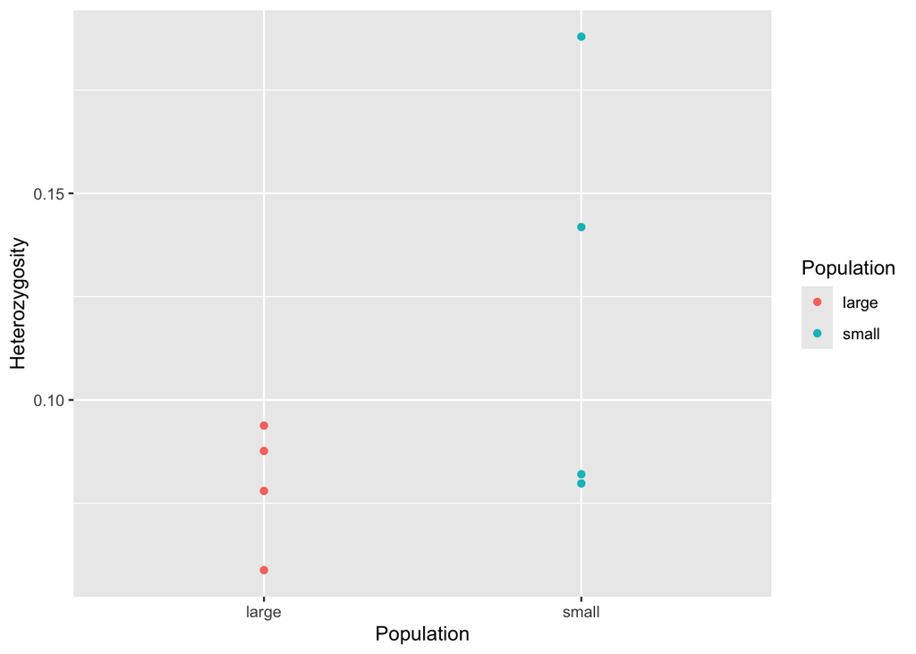

```r
A <- ggplot(het,aes(x = Population, y = Heterozygosity, col = Population)) +
  geom_point()

A
```

Now we need to change the background colour. I did this by adding a layer called `theme_bw()`. Check out ggplots `themes` online for more:

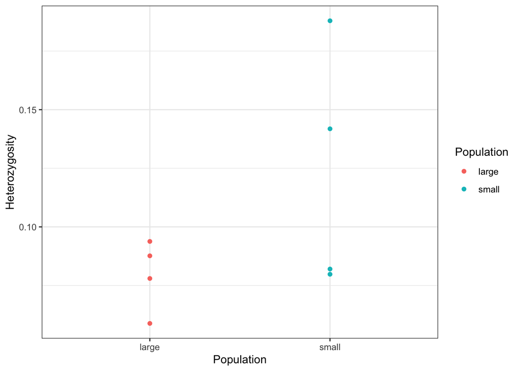

```r
A <- ggplot(het,aes(x = Population, y = Heterozygosity, col = Population)) +
  geom_point()+
  theme_bw()

A
```

Add the panel label:

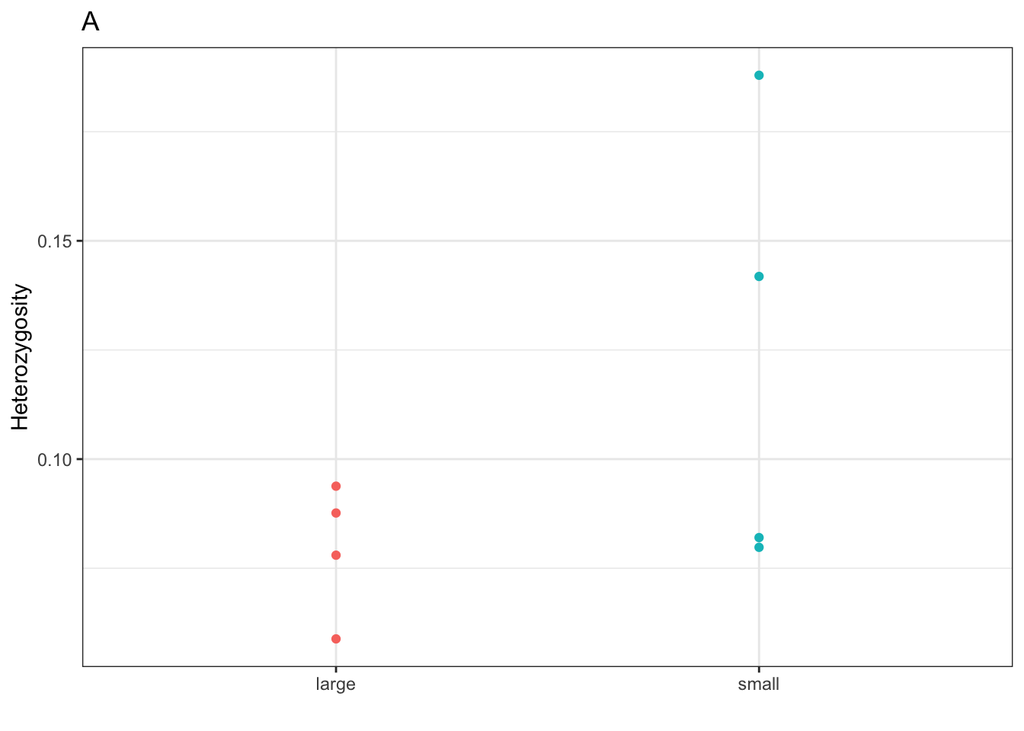

```r
A <- ggplot(het,aes(x = Population, y = Heterozygosity, col = Population)) +
  geom_point()+
  theme_bw()+
  theme(legend.position = "none")+
  xlab("")+
  ggtitle("A")

A
```

And we’re there! Now let’s move onto panel B, which is slightly more complicated. Again, we first look at the data. Remember we have two data frames for the nucleotide diversity data - one for each population:

```r
pi_large
```

```
## # A tibble: 383 × 5
##    CHROM BIN_START BIN_END N_VARIANTS      PI
##    <dbl>     <dbl>   <dbl>      <dbl>   <dbl>
##  1     0         1    2000         40 0.00775
##  2     0      2001    4000         56 0.0104
##  3     0      4001    6000         57 0.0102
##  4     0      6001    8000         48 0.00953
##  5     0      8001   10000         58 0.0111
##  6     0     10001   12000         40 0.00679
##  7     0     12001   14000         43 0.00789
##  8     0     14001   16000         50 0.00977
##  9     0     16001   18000         46 0.00863
## 10     0     18001   20000         58 0.0108
## # ℹ 373 more rows
```

```r
pi_small
```

```
## # A tibble: 384 × 5
##    CHROM BIN_START BIN_END N_VARIANTS      PI
##    <dbl>     <dbl>   <dbl>      <dbl>   <dbl>
##  1     0         1    2000         45 0.00858
##  2     0      2001    4000         55 0.0115
##  3     0      4001    6000         66 0.0143
##  4     0      6001    8000         58 0.0113
##  5     0      8001   10000         59 0.0115
##  6     0     10001   12000         45 0.00955
##  7     0     12001   14000         45 0.00925
##  8     0     14001   16000         50 0.00979
##  9     0     16001   18000         45 0.00921
## 10     0     18001   20000         64 0.0130
## # ℹ 374 more rows
```

Because ggplot likes to work from a single data frame, we first need to combine our data from the two populations and add a population ID column

```r
pi_both <- bind_rows(pi_large,pi_small)
pi_both$Population <- c(rep("large",nrow(pi_large)),rep("small",nrow(pi_small)))
```

Now we are ready to make a plot. We will start with the `box plot`. Remember that we can use a lot of the same arguments from our previous plot. But this time we will use `geom_boxplot()` instead of `geom_point()`

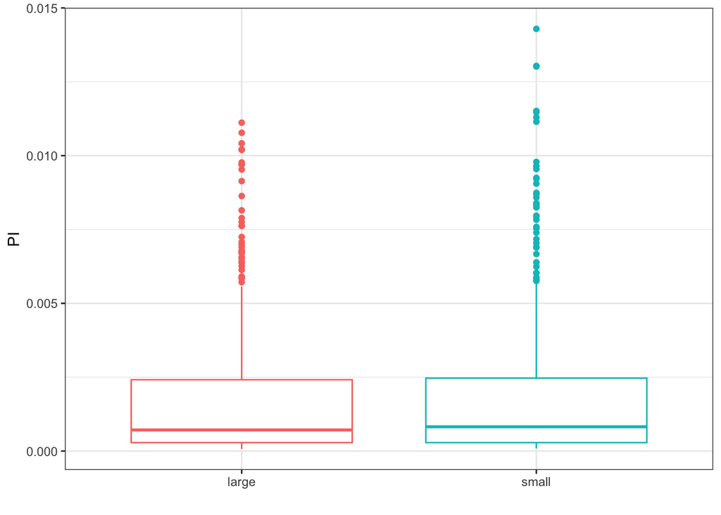

```r
B <- ggplot(pi_both,aes(x = Population, y = PI, col = Population)) +
      geom_boxplot()+
      theme_bw()+
      theme(legend.position = "none")+
      xlab("")
B
```

We can add a notch to the box plot and remove the outliers (google!):

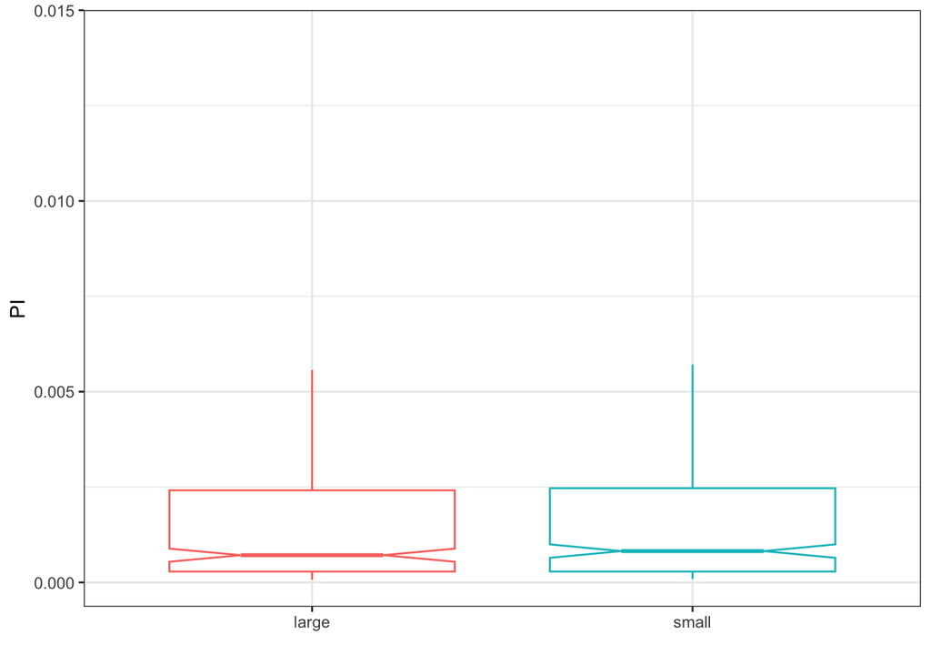

```r
B <- ggplot(pi_both,aes(x = Population, y = PI, col = Population)) +
      geom_boxplot(notch = T,outlier.shape = NA)+
      theme_bw()+
      theme(legend.position = "none")+
      xlab("")
B
```

To add the points behind the box plot we will use the function geom_jitter:

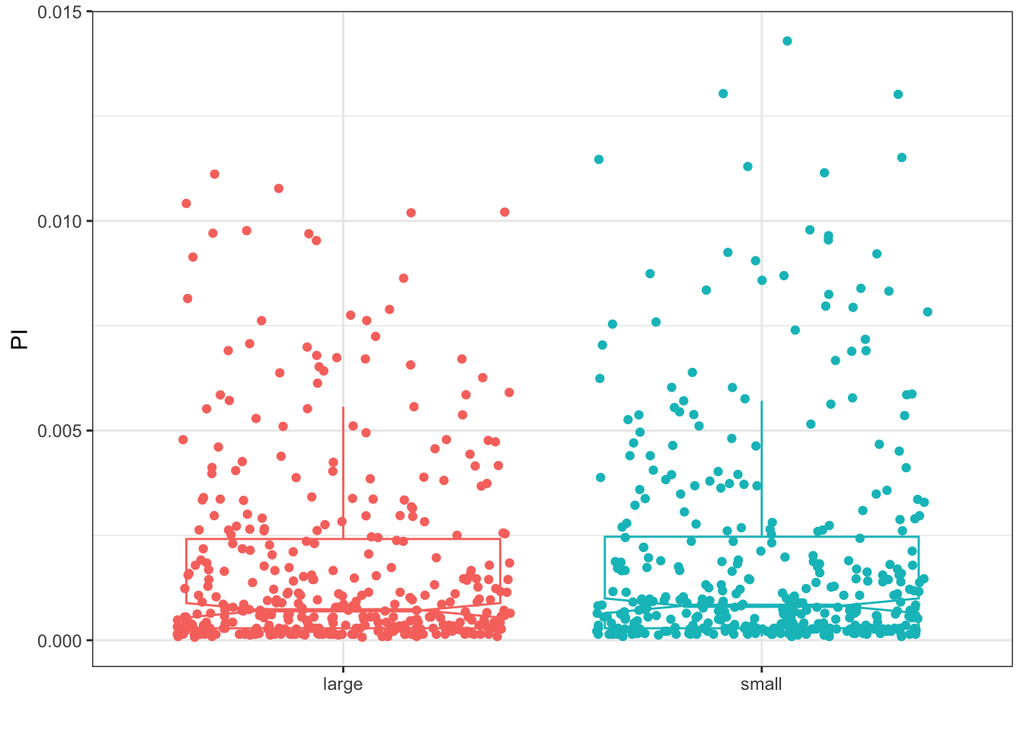

```r
B <- ggplot(pi_both,aes(x = Population, y = PI, col = Population)) +
      geom_boxplot(notch = T,outlier.shape = NA)+
      theme_bw()+
      theme(legend.position = "none")+
      xlab("")+
      geom_jitter()
B
```

There are two problems here. First, the points are getting in the way of the box plots. Second, they have been coloured by population whereas we would like them to be grey. Any idea how we fix these things?

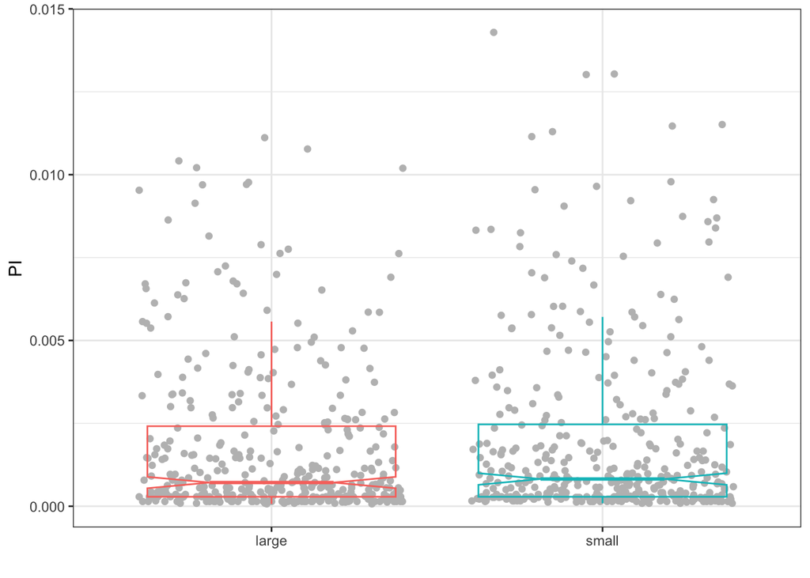

```r
B <- ggplot(pi_both,aes(x = Population, y = PI, col = Population))+
      geom_jitter(col = "grey")+ #Add this before the geom_boxplot() to put the points behind the boxes
      geom_boxplot(notch = T, alpha = 0,outlier.shape = NA)+ #alpha makes the background seethrough
      theme_bw()+
      theme(legend.position = "none")+
      xlab("")

B
```

Getting there… the points in this plot are spread more widely here than in the plot above though. Do you know how we can pack them in more?

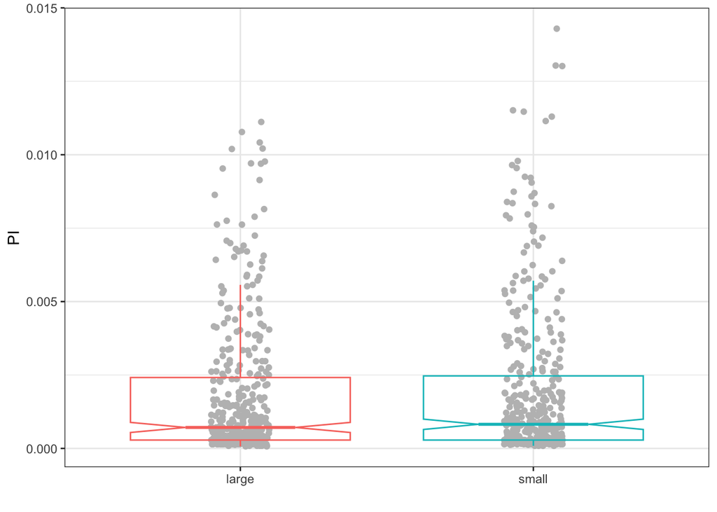

```r
B <- ggplot(pi_both,aes(x = Population, y = PI, col = Population))+
      geom_jitter(col = "grey",width = 0.1)+ #Add this before the geom_boxplot() to put the points behind the boxes
      geom_boxplot(notch = T, alpha = 0,outlier.shape = NA)+ #alpha makes the background seethrough
      theme_bw()+
      theme(legend.position = "none")+
      xlab("")

B
```

Finally, we just need to add the panel label and sort out our y axis. How can we add a symbol? (Hint - look up expression()):

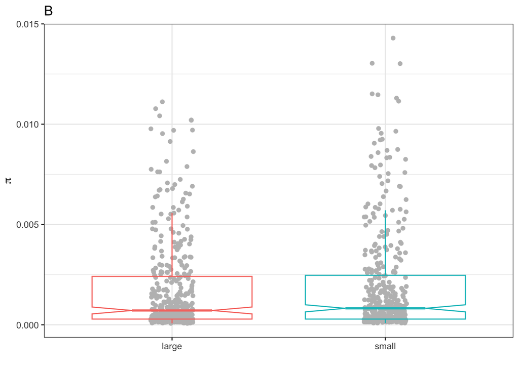

```r
B <- ggplot(pi_both,aes(x = Population, y = PI, col = Population))+
      geom_jitter(col = "grey",width = 0.1)+ #Add this before the geom_boxplot() to put the points behind the boxes
      geom_boxplot(notch = T, alpha = 0,outlier.shape = NA)+ #alpha makes the background seethrough
      theme_bw()+
      theme(legend.position = "none")+
      xlab("")+
      ylab(expression(pi))+
      ggtitle("B")
B
```

Ok, we have done our plots! We now need to make a single, `muti-panel plot`. Again, there are lots of ways we can do this and this is definitely something you should explore. For now we will use the `multiplot()` function from the `Rmisc` library. We can just list the plots without specifying anything to do with the layout:

```r
library(Rmisc)
```

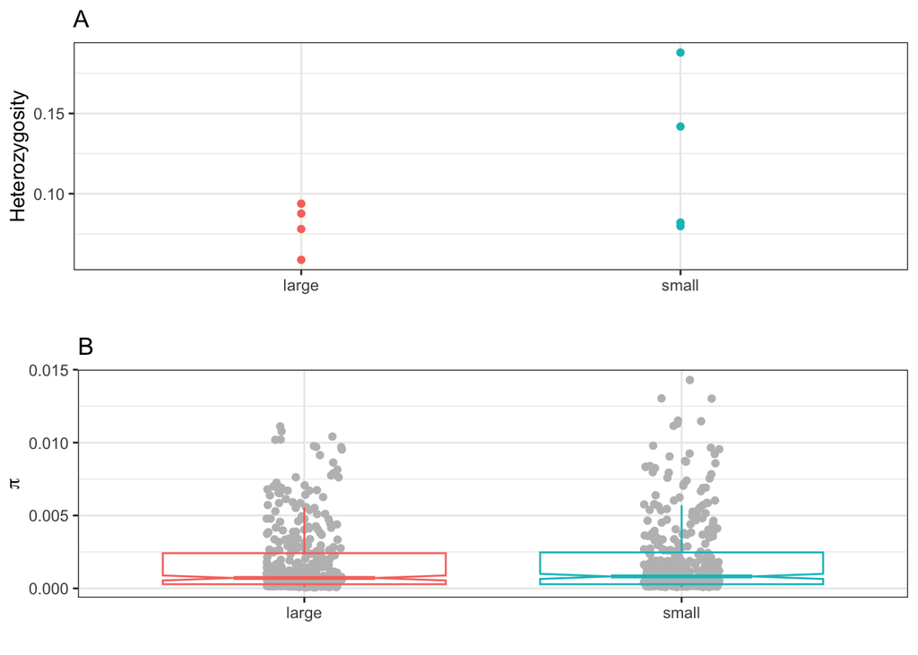

```r
multiplot(A,B)
```

### Congratulations!! You have made a plot of heterozygosity and nucleotide diversity

### If you have finished

Can you try making these plots based on populations? (Pop-A & Pop-C). Which population has the highest heterozygosity and nucleotide diversity?